# Midterm_yutian

Yutian Luo

# Dataset Exploratory analysis/visualization

## Overview

The data is originatd from https://www.kaggle.com/arashnic/hr-analytics-job-change-of-data-scientists. The original dataset was pre-partitioned with training data of 19158 observations with 14 variables and testing data of 2129 observations with 13 variables (without response variable `target`).

The independent variables include `city`, `city development index`, `gender`, `relevant experience`, `education level`, `company type` and so on. Our goal is to construct classification and regression models to predict the possibility that a single candidate will look for a new job in the job market.

## Data Exploratory

The potential problem in the default data is missing data. The original data has 7.7% of missing data.

From (**Fig. missing**), we see that most of missing data are from `company type`, `company size`, `gender`, and `major discipline`. If simply drop the observations missing these information, there will be bias and almost half of data will be eliminated. Thus, we need to consider possibility of imputation.

To perform imputation, we first check missing mechanism. From (**Fig. missing2**), we see the intersection and amount of missingness. As we can see, the largest amount of missing (2777) is when `company type` and `company size` are both missing, while the second largest amount of missing (2224) is when `gender` alone is missing. So we can see that most of the missing has to do with `company size` and `company type` not recorded and the same time.

After reviewing these plots, we cannot see if the missingness is from a non-random element. It seems that for those who didn’t record company size, they also weren’t recorded for company type, this might be from recording error. Thus, the missingness from these three variables are assumed to have MAR relation. Thus, we continue to perform imputation.

# Models

## Random Forest as a baseline model

### Logistics Regression

In logistics regression, we achieved sensitivity in 0.7853 and specificity in 0.6290. The agreement between predictive value and true value, is 0.3184;

In logistics regression, we achieved a satisfactory ROC, which is 0.76. However, when setting initial p>0.5, the sensitivity is very low.

### LDA Model

For LDA, although for continous features it has assumption on normality, our data is mainly categorical/classification problem. Thus, LDA’s robustness in assumption takes an advantage here. In LDA model we achieved a 0.763 ROC. However, we should note that LDA is generally used when K>2 or n is small.

### QDA Model

When Assumine the sum of gaussian densities are in different covariance matrix, we use Quadratic Discriminant Analysis. In our case, we hope that LDA and QDA would have similar result and prediciton. The QDA achieved a 0.698 ROC.

## Model Comparison

We obtain testing data ROC for each model. By comparing the ROC and looking at accuracy, we selected the MARS model as our final model for predicting `target`.

# Conclusion

In this project, we built several regression models to predict a data scientists’ decision to look for a new job - `target`, which is an important parameter for determining the probability of the decision. We tuned the models and selected the best model for prediction.

Original Training Data Summary

|  | enrollee_id | city | city_development_index | gender | relevant_experience | enrolled_university | education_level | major_discipline | experience | company_size | company_type | last_new_job | training_hours | target |
| --- | --- | --- | --- | --- | --- | --- | --- | --- | --- | --- | --- | --- | --- | --- |
|  | Min. : 1 | city_103:4355 | 0.92 :5200 | Female: 1238 | Has relevant experience:13792 | Full time course: 3757 | Graduate :11598 | Arts : 253 | >18 :13860 | 50-99 :3083 | Early Stage Startup: 603 | >4 :3290 | Min. : 1.00 | 0:14381 |
|  | 1st Qu.: 8554 | city_21 :2702 | 0.624 :2702 | Male :13221 | No relevant experience : 5366 | no_enrollment :13817 | High School : 2017 | Business Degree: 327 | 4-6 : 1298 | 100-500 :2571 | Funded Startup :1001 | 1 :8040 | 1st Qu.: 23.00 | 1: 4777 |
|  | Median :16983 | city_16 :1533 | 0.91 :1533 | Other : 191 | NA | Part time course: 1198 | Masters : 4361 | Humanities : 669 | 1-3 : 1038 | 10000+ :2019 | NGO : 521 | 2 :2900 | Median : 47.00 | NA |
|  | Mean :16875 | city_114:1336 | 0.926 :1336 | NA’s : 4508 | NA | NA’s : 386 | Phd : 414 | No Major : 223 | 8-10 : 916 | 10/49 :1471 | Other : 121 | 3 :1024 | Mean : 65.37 | NA |
|  | 3rd Qu.:25170 | city_160: 845 | 0.698 : 683 | NA | NA | NA | Primary School: 308 | Other : 381 | 14-16 : 600 | 1000-4999:1328 | Public Sector : 955 | 4 :1029 | 3rd Qu.: 88.00 | NA |
|  | Max. :33380 | city_136: 586 | 0.897 : 586 | NA | NA | NA | NA’s : 460 | STEM :14492 | (Other): 1381 | (Other) :2748 | Pvt Ltd :9817 | never:2452 | Max. :336.00 | NA |
|  | NA | (Other) :7801 | (Other):7118 | NA | NA | NA | NA | NA’s : 2813 | NA’s : 65 | NA’s :5938 | NA’s :6140 | NA’s : 423 | NA | NA |

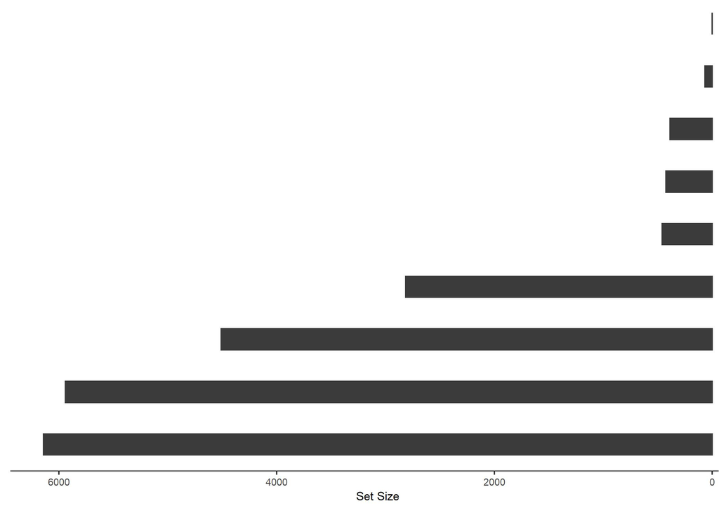

**Fig. Missing Data Intersection Plot**

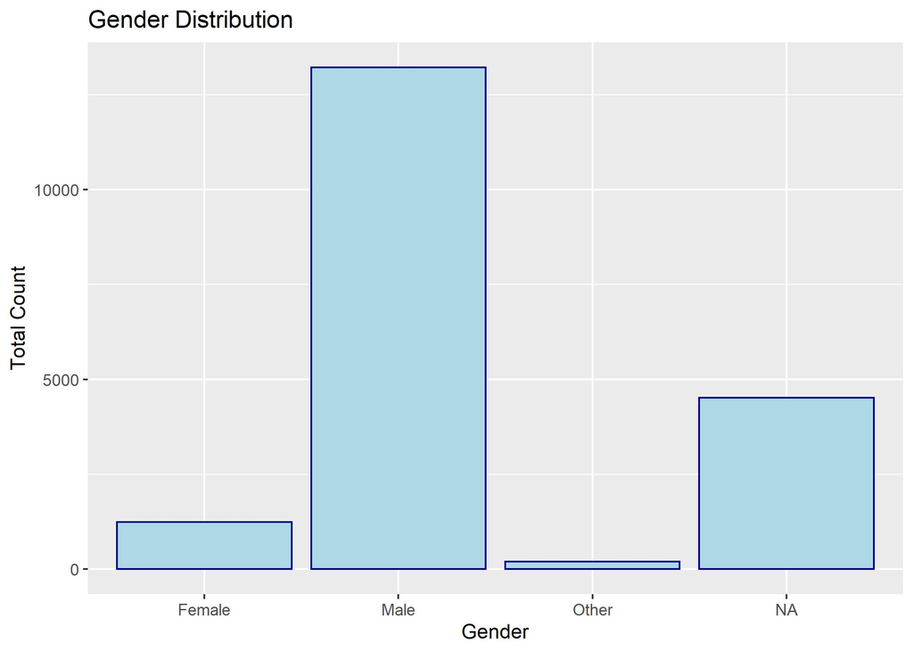

**Fig. Missing Data gender**

[figure not shown]

**Fig. company size and type**

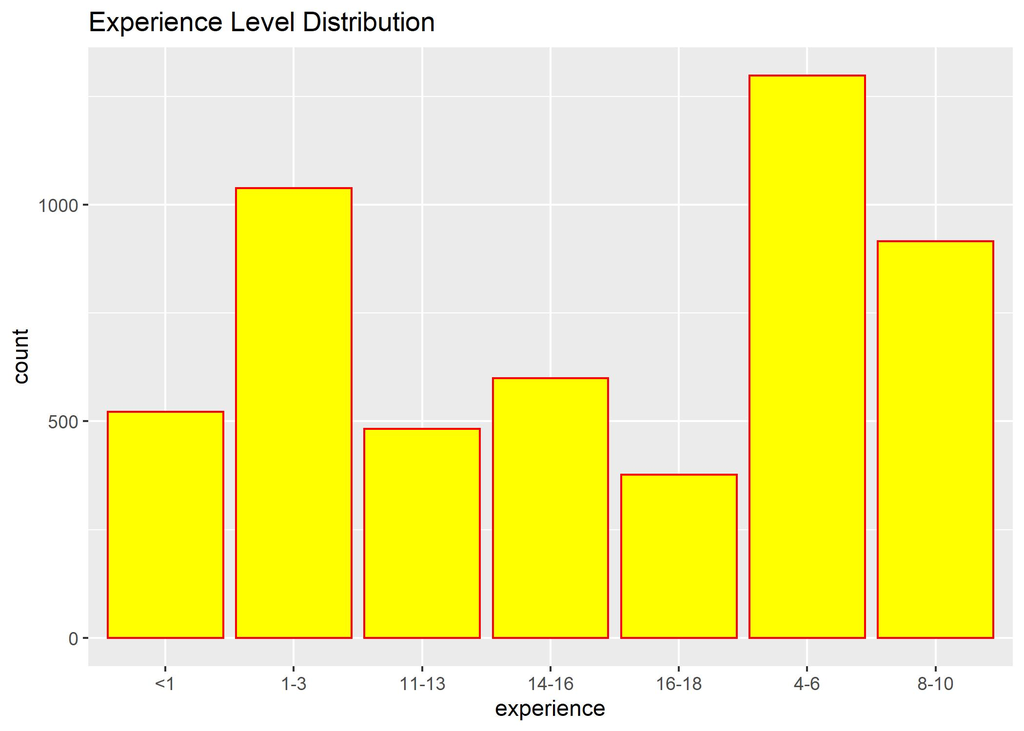

**Fig. Candidate Experience Years**

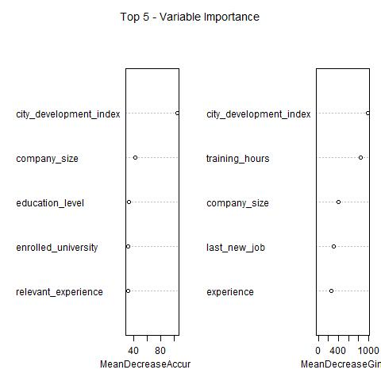

**Fig. random forest top5 important variable**

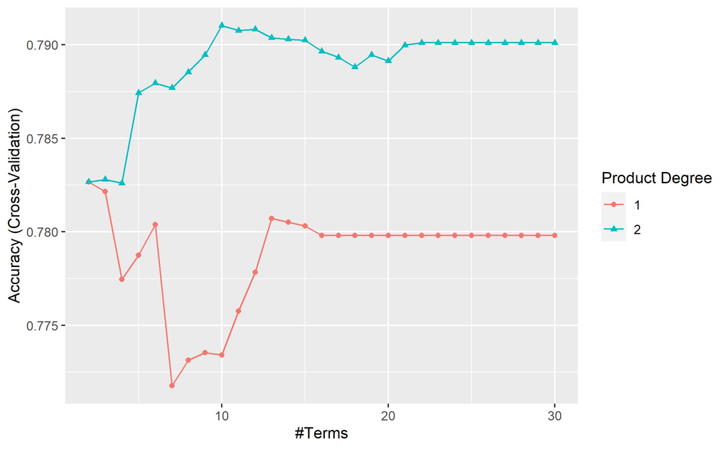

**Fig. Mars fitting**

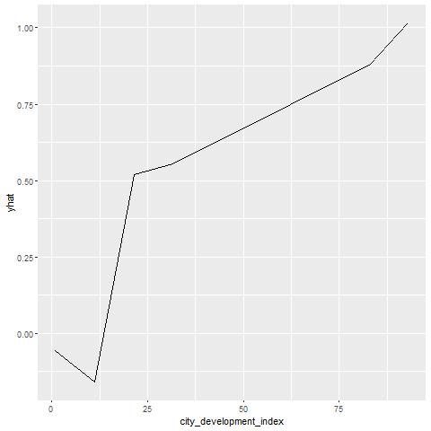

**Fig. mars partial plot**

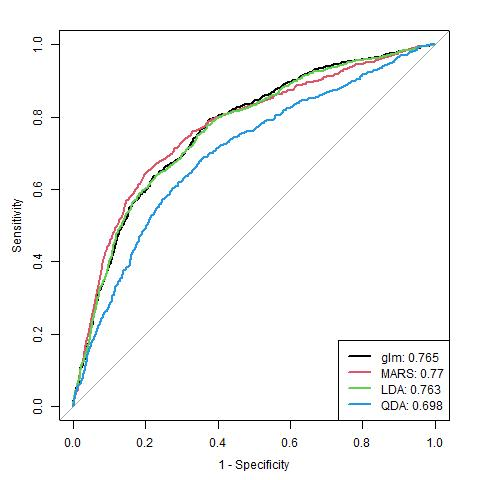

**Fig. 5 Model Comparison**